# Simulated Annealing and Mutual Information

Lou Zhang

April 5th, 2017

### Introduction

Simulated Annealing and Mutual Information are methods for determining feature relevance when presented with a multivariate problem. This document will discuss a brief theoretical background behind these methods, the code used to execute them in R, an evaluation of the results, and their suitability for the EAA project.

The data has been pre-processed to be stationary and remove heteroskedasticity. A table is loaded with cleaned data from IDDS before any algorithms are executed.

### Simulated Annealing

Simulated Annealing comes from the concept of annealing in metalworking, when metalworkers would heat a piece of metal to a very high temperature and then let it cool in a controlled fashion. As it cooled, the metalworkers would alter the properties of the piece of metal to the optimal shape, size, and properties.

In the 1980s, engineers took this idea and used it to “simulate annealing” in computer programs to find the optimal set of variables from a larger set of variables. The algorithm starts very “hot” and jumps around in the feature space to try and find the local optimas, but as it “cools”, settles on a tighter location with the highest likelihood of finding the global optimum to isolate the optimal combination of variables.

The key advantage behind simulated annealing is its ability to quickly find the optimal combination of variables, which represents the feature space optimally tuned to predict the target variable.

An illustration can be seen below:

*Simulated Annealing in Action - notice how the algorithm iterates to find the global optimum*

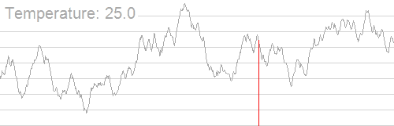

The literature suggests that simulated annealing is not entirely appropriate for time series. A paper published by the Head of Quantitative Research at JP Morgan specifically points this out:

*“SA looks highly promising for portfolio optimisation and asset allocation problems [which are not time series problems], because the driving variables are highly nonlinear, noisy and often chaotic; it appears less appropriate for modelling financial time series.” [http://www.aiinfinance.com/saweb.pdf]*

### Execute Simulated Annealing Algorithm

```r
sc <- safsControl(functions = rfSA,
                  method = "repeatedcv",
                  repeats = 5,
                  improve = 50)

obj <- safs(x = MonthlySeriesA,
            y = oilProductionByMonth[[1]],
            iters = 5, safsControl = sc)

vars <- as.data.frame(sort(table(unlist(obj$resampled_vars)), decreasing = TRUE))

vars$description <- vlookup(ref = vars$Var1,table = reftable[,2:ncol(reftable)],column = 11)
```

```r
vars$description <- substr(vars$description, 1, 40)

head(vars[,2:3], 20)
```

```
##    Freq                              description
## 1    24 Australia, Cross Exchange Rate (to yen),
## 2    21 Singapore, Growth Rate: Broad Money Supp
## 3    20 Taiwan, Nominal Customs Clearance Import
## 4    20 Spain, Money Supply M3, Period End, SA,
## 5    19 Indonesia, Industrial Production, SA, Un
## 6    19 Canada, Broad Money Supply, Period End,
## 7    19 Japan, Growth Rate: Retail Sales, Nomina
## 8    19 Australia, Interest Rate: Money Market,
## 9    18 Australia, Money Supply M3, Period End,
## 10   18 Mexico, Consumer Price Index, SA, Units:
## 11   18 United Kingdom, Nominal Customs Clearanc
## 12   18 Italy, Exchange Rate, Period Average, Un
## 13   18 Japan, Exchange Rate, Period Average, Un
## 14   18 China, Exchange Rate, Period Average, Un
## 15   18 Egypt, Exchange Rate, Period Average, Un
## 16   18 South Korea, Inflation Rate: Wholesale/P
## 17   18 Saudi Arabia, Growth Rate: Nominal Custo
## 18   18 India, Cross Exchange Rate (to yen), Per
## 19   17 Netherlands, Consumer Price Index, SA, U
## 20   17 Venezuela, Consumer Price Index, Caracas
```

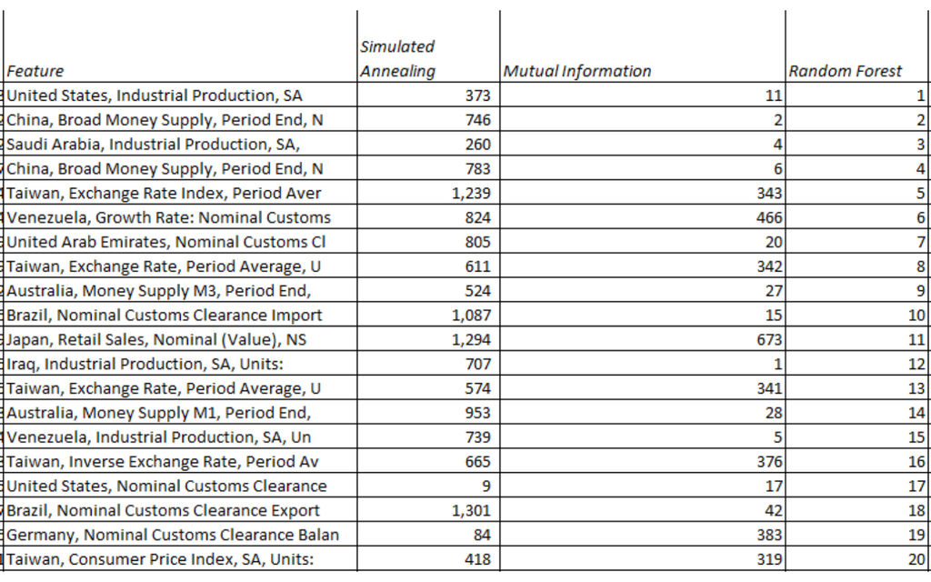

### Mutual Information

Mutual Information is a way to evaluate the “relatedness” of two series in a nonlinear fashion. It can be thought of as the amount of information gained about one variable from knowing about another variable. It measures how much “information” two series share, and therefore how much uncertainty is reduced in one series by knowing about another. Mathematically, it is expressed as:

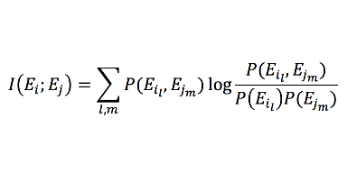

where $p(E_{ij},E_{jm})$ is the joint probability distribution function of $E_{ij}$ and $E_{jm}$, and $p(E_{ij})$ and $p(E_{jm})$) are the marginal probability distribution functions of $E_{ij}$ and $E_{jm}$ respectively. Essentially, it measures the amount of uncertainty reduced in one variable just by knowing about the values of another variable.

### Execute Mutual Information Algorithm

```r
#discretize the data into 4 bins - must be discretized to use package

a <- MonthlySeriesA

aDisc <- as.data.frame(1:nrow(a))

for(i in 1:ncol(a)){

aDisc[i] <- discretize(a[i] , nbins = 4)

}

oilProductionByMonthDisc <- discretize(oilProductionByMonth, nbins = 4)

colnames(oilProductionByMonthDisc) <- 'Oil Production Discretized'

head(oilProductionByMonthDisc, 20)
```

```
##    Oil Production Discretized
## 1                           2
## 2                           1
## 3                           4
## 4                           1
## 5                           1
## 6                           1
## 7                           4
## 8                           4
## 9                           2
## 10                          2
## 11                          4
## 12                          1
## 13                          1
## 14                          3
## 15                          1
## 16                          1
## 17                          4
## 18                          3
## 19                          3
## 20                          3
```

```r
#execute MI algorithm

k <- as.data.frame(1:ncol((a)))

for(i in 1:ncol(aDisc)){
  b <- mutinformation(oilProductionByMonthDisc, aDisc[i])
  k[i,] <- b
}

rownames(k) <- colnames(a)

MutInfo <- k
MutInfo$description <- vlookup(ref = rownames(MutInfo),table = reftable[,2:ncol(reftable)],column = 11)

MutInfo$description <- substr(MutInfo$description, 1, 60)

MutInfoUnique <- MutInfo[!duplicated(MutInfo$description), ]

MutInfoUnique <- na.omit(MutInfoUnique)

colnames(MutInfoUnique) <- c('Mutual Information','Description')

MutInfoUnique <- as.data.frame(MutInfoUnique[ order(-MutInfoUnique[,1]), ])

rownames(MutInfoUnique) <- MutInfoUnique$Description

head(MutInfoUnique[1], 20)
```

```
##                                                              Mutual Information
## Norway, Industrial Production, SA, Units: index, base year 2         0.07407913
## United Arab Emirates, Money Supply M2, Period End, NSA, Unit         0.07379087
## United Kingdom, Consumer Price Index, NSA, Units: LCU price          0.07066277
## Mexico, Unemployment Rate, SA, Units: percent, Data source:          0.07011088
## Japan, Interest Rate: Long Term: 10-year Japanese government         0.06967873
## Australia, Unemployment Rate, NSA, Units: percent, Data sour         0.06835464
## Venezuela, Growth Rate: Industrial Production, Year-on-Year,         0.06826019
## United Arab Emirates, Broad Money Supply, Period End, NSA, U         0.06762183
## Iraq, Industrial Production, NSA, Units: index, base year 20         0.06549418
## Venezuela, Industrial Production, NSA, Units: index, base ye         0.06431154
## Australia, Retail Sales, Nominal (Value), NSA, Units: index,         0.06350476
## Italy, Nominal Customs Clearance Imports: Total, SA, Units:          0.06266203
## Taiwan, Unemployment Rate, NSA, Units: percent, Data source:         0.06240569
## Italy, Industrial Production, NSA, Units: index, base year 2         0.06204629
## China, Short Term Interest Rate Differential With the USA, U         0.06087691
## China, Retail Sales, Nominal (Value), SA, Units: US$ index,          0.06068580
## China, Retail Sales, Real (Volume), SA, Units: index, base y         0.06038504
## Kuwait, Broad Money Supply, Period End, SA, Units: billion K         0.06012571
## Kuwait, Money Supply M3, Period End, SA, Units: billion Kuwa         0.06012571
## Netherlands, Growth Rate: Industrial Production, Year-on-Yea         0.05995989
```

```r
#discretize the data into 20 bins - observe differences

a <- MonthlySeriesA

aDisc <- as.data.frame(1:nrow(a))

for(i in 1:ncol(a)){

aDisc[i] <- discretize(a[i] , nbins = 20)

}

oilProductionByMonthDisc <- discretize(oilProductionByMonth, nbins = 20)

colnames(oilProductionByMonthDisc) <- 'Oil Production Discretized'

head(oilProductionByMonthDisc, 20)
```

```
##    Oil Production Discretized
## 1                          10
## 2                           2
## 3                          20
## 4                           1
## 5                           2
## 6                           1
## 7                          20
## 8                          18
## 9                           6
## 10                          7
## 11                         19
## 12                          5
## 13                          6
## 14                         13
## 15                          5
## 16                          2
## 17                         18
## 18                         14
## 19                         16
## 20                         12
```

```r
#execute MI algorithm

k <- as.data.frame(1:ncol((a)))

for(i in 1:ncol(aDisc)){
  b <- mutinformation(oilProductionByMonthDisc, aDisc[i])
  k[i,] <- b
}

rownames(k) <- colnames(a)

MutInfo <- k
MutInfo$description <- vlookup(ref = rownames(MutInfo),table = reftable[,2:ncol(reftable)],column = 11)

MutInfo$description <- substr(MutInfo$description, 1, 60)

MutInfoUnique <- MutInfo[!duplicated(MutInfo$description), ]

MutInfoUnique <- na.omit(MutInfoUnique)

colnames(MutInfoUnique) <- c('Mutual Information','Description')

MutInfoUnique <- as.data.frame(MutInfoUnique[ order(-MutInfoUnique[,1]), ])

rownames(MutInfoUnique) <- MutInfoUnique$Description

head(MutInfoUnique[1], 20)
```

```
##                                                              Mutual Information
## Kuwait, Money Supply M3, Period End, NSA, Units: billion Kuw           1.098183
## Iran, Growth Rate: M1 Money Supply in US$, Year-on-Year, Uni           1.076522
## Australia, Cross Exchange Rate (to euro), Period Average, Un           1.073797
## Norway, Growth Rate: Nominal Customs Clearance Imports in U.           1.064807
## Mexico, Short Term Interest Rate Differential With the USA,            1.061517
## Norway, Short Term Interest Rate Differential With the USA,            1.059356
## Brazil, Short Term Interest Rate Differential With the USA,            1.057586
## Italy, Nominal Customs Clearance Exports: Total, SA, Units:            1.052136
## Norway, Inverse Exchange Rate, Period Average, Units: US$ pe           1.051556
## Australia, Money Supply M4, Period End, SA, Units: billion U           1.051180
## China, Wholesale/Producer Price Index, SA, Units: LCU price            1.048001
## Germany, Nominal Customs Clearance Balance, SA, Units: billi           1.046685
## Indonesia, Inflation Rate: Consumer Price Index, Year-on-Yea           1.046685
## China, Inverse Exchange Rate, Period End, Units: US$ per Chi           1.045458
## United States, Retail Sales, Real (Volume), SA, Units: index           1.045276
## Australia, Money Supply M3, Period End, NSA, Units: billion            1.043960
## Netherlands, Nominal Customs Clearance Imports: Total, SA, U           1.042190
## Iran, Money Supply M1, Period End, NSA, Units: billion US$,            1.042190
## Egypt, Growth Rate: Broad Money Supply, Year-on-Year, Units:           1.042190
## Germany, Retail Sales, Nominal (Value), NSA, Units: index, b           1.040958
```

### Conclusions

As we can see, mutual information is the superior of the two methods - it is able to process time series data and gives us more meaningful features, which are alinged with the other feature selection methods.

Mutual information should be tuned before used for feature selection - the discretization and variable transforms can drastically change the outcome of our results.

Simulated annealing is not appropriate for time series data, and this is confirmed with a quick empirical test, yielding results which are drastically dissimilar from other better-known methods.